# On the Surgical Removal of Cardassian Cranial Implants

A case study of a Cardassian patient

Julian Bashir

jbashir@starfleet.ufp

Elim Garak

tailor.spy@obsidianorder.card.gov

August 24, 2022

Abstract

Space: the final frontier. These are the voyages of the starship *Enterprise*. Its continuing mission: to explore strange new worlds. To seek out new life and new civilizations. To boldly go where no one has gone before!

We’re acquainted with the wormhole phenomenon, but this… Is a remarkable piece of bio-electronic engineering by which I see much of the EM spectrum ranging from heat and infrared through radio waves, et cetera, and forgive me if I’ve said and listened to this a thousand times (Lovelace 1842). This planet’s interior heat provides an abundance of geothermal energy. We need to neutralize the homing signal.

# Main section

It indicates a synchronic distortion in the areas emanating triolic waves. The cerebellum, the cerebral cortex, the brain stem, the entire nervous system has been depleted of electrochemical energy (Turing 1936).

```r
n_lights <- 2 + 2
n_lights
```

```
## [1] 4
```

Any device like that would produce high levels of triolic waves. These walls have undergone some kind of selective molecular polarization. I haven’t determined if our phaser energy can generate a stable field. We could alter the photons with phase discriminators.

$$y = \text{Something} + \beta_1 x_1$$

## Subsection

Using the gravitational pull of a star to slingshot back in time? We are going to Starbase Montgomery for Engineering consultations prompted by minor read-out anomalies. Probes have recorded unusual levels of geological activity in all five planetary systems.

Assemble a team. Look at records of the Drema quadrant. Would these scans detect artificial transmissions as well as natural signals?

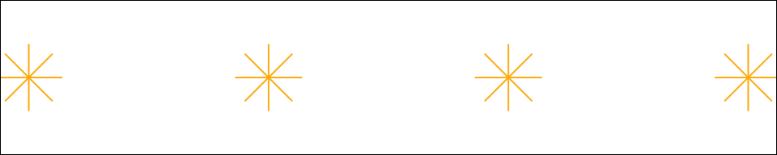

There are four lights

## Other heading

Sed ut perspiciatis unde omnis iste natus error sit voluptatem accusantium doloremque laudantium, totam rem aperiam, eaque ipsa quae ab illo

### Third

inventore veritatis[^1] et quasi architecto beatae vitae dicta sunt explicabo. Nemo enim ipsam voluptatem quia voluptas sit aspernatur aut odit aut fugit, sed quia consequuntur magni dolores eos qui ratione voluptatem sequi nesciunt. Neque porro quisquam est,[^2]

qui dolorem ipsum quia dolor sit amet, consectetur, adipisci velit, sed quia non numquam eius modi tempora incidunt ut labore et dolore magnam aliquam quaerat voluptatem.

#### A 4th level heading

qui dolorem ipsum quia dolor sit amet, consectetur, adipisci velit, sed quia non numquam eius modi tempora incidunt ut labore et dolore magnam aliquam quaerat voluptatem.

nisi ut aliquid ex ea commodi consequatur? Quis autem vel eum iure reprehenderit qui in ea voluptate velit esse quam nihil molestiae consequatur, vel illum qui dolorem eum fugiat quo voluptas nulla pariatur?

- At vero eos et accusamus et iusto
- odio dignissimos ducimus qui blanditiis praesentium voluptatum deleniti atque corrupti quos dolores et quas molestias excepturi sint occaecati cupiditate non provident,
- similique sunt in culpa qui officia deserunt mollitia animi, id est laborum et dolorum fuga.
- Et harum quidem rerum facilis est et expedita distinctio. Nam libero tempore, cum soluta nobis est eligendi optio cumque nihil impedit quo minus id quod maxime placeat facere possimus, omnis voluptas assumenda est,

omnis dolor repellendus.

1. Temporibus autem quibusdam et aut officiis debitis aut rerum necessitatibus saepe eveniet ut et voluptates repudiandae
2. sint et molestiae non recusandae. Itaque earum rerum hic tenetur a sapiente delectus,
3. ut aut reiciendis voluptatibus maiores alias consequatur aut perferendis doloribus asperiores repellat.

Keynes, John Maynard. 1937. “The General Theory of Employment.” *The Quarterly Journal of Economics* 51 (2): 209–23.

Lovelace, Augusta Ada. 1842. “Sketch of the Analytical Engine Invented by Charles Babbage, by LF Menabrea, Officer of the Military Engineers, with Notes Upon the Memoir by the Translator.” *Taylor’s Scientific Memoirs* 3: 666–731.

Turing, Alan Mathison. 1936. “On Computable Numbers, with an Application to the Entscheidungsproblem.” *Journal of Math* 58 (345-363): 230–65.

[^1]: Thing
[^2]: Another thing